# 411A Advisor Emails

## SUBJECT

MEDS Capstone Updates - Winter Week X

## Week 2

Hello MEDS Capstone Advisors,

I hope you are doing great.

This is your weekly EDS 411 - MEDS Capstone project newsletter. Please feel free to reach out with any questions or suggestions.

Best wishes,

Carmen

Carmen Galaz García | Assistant Teaching Professor  
Bren School of Environmental Science and Management  
University of California, Santa Barbara  
(she / her / hers)

[EDS 411 Course website](https://meds-eds-411.github.io/eds-411-website/)

**[Capstone guidelines](https://bren.ucsb.edu/sites/default/files/Capstone%20Project%20Guidelines%20MEDS%202026.pdf)**

Upcoming Major Deadlines

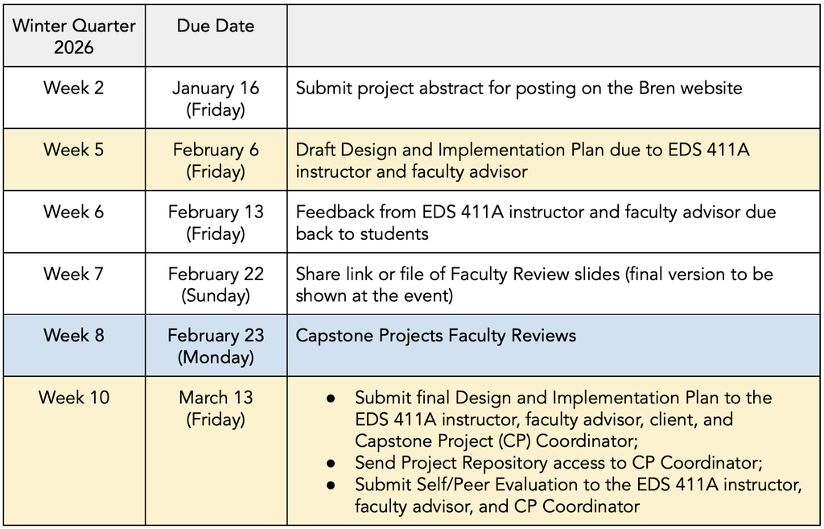

Advisor Check-ins

- All groups should get their advisor’s feedback and approval on their project summary before submitting it this Friday 1/16.
- Students might reach out about feedback on section VII of the [Team Management Plan](https://docs.google.com/document/d/1YBmS08NpSCTVcrys98lKlY6n3IcWvj0Cn7xIJABtxMU/edit?tab=t.0). This section outlines overall work expectations between team members and their faculty advisor.
- Students will start working on their Design and Implementation Plan this week. The DIP is the primary written academic deliverable for students this term. You can find all the details in the [Capstone guidelines](https://bren.ucsb.edu/sites/default/files/Capstone%20Project%20Guidelines%20MEDS%202026.pdf) and read some sample DIPs from previous years [here](https://drive.google.com/drive/folders/1ZpxTPDm0DlXn3fzkpcM3sYRfnY4gTM7I?usp=share_link). The format has been slightly updated this year, but these examples are still useful to have in mind.
- In week 5, advisors will review a complete draft of their group’s DIP, but students might contact you with questions or feedback before this.
- Students can and should keep working on data analysis and deliverables while writing their DIP!

In 411A Today [(slides @ website)](https://meds-eds-411.github.io/eds-411-website/411a_winter/week2.html)

- Each group gave a 3-minute presentation with an overview of their project and a graph showing preliminary data exploration
- [Computing resources presentation](https://docs.google.com/presentation/d/1dO3eNAM37yjKQTQIkV5zbGcYkfb9Yhph1A32mHA4ErY/edit?slide=id.ge6b7f452cd_0_6982#slide=id.ge6b7f452cd_0_6982) - Kat Le, Bren School’s Technical Applications Manager, covering Google groups, shiny app deployment, and other computer resources
- Each team created a GitHub organization where they will host their project’s code repositories. We also explored GitHub issues, milestones, and projects as a tool for project management.
- Overview of DIP’s Problem Statement and Objectives and Products and Deliverables sections, and group work.

Tasks all groups are expected to complete before next 411A class:

1. Due Friday 1/16: Summary paragraph for Bren website with advisor approval
2. Due Tuesday 1/20: Team Management Plan draft
3. Due Tuesday 1/20: Draft of DIP Team Management Plan, DIP Summary, Objectives, and Deliverables sections.
4. Fill out a [questionnaire about their Data Management Plan](https://docs.google.com/document/d/1dLV5RK3_sVuX-jbL0QaqaeFAa1JZ6cxo7nwfGUWjX7s/edit?usp=sharing) in preparation for meeting with the Research Data Services from UCSB’s Library this week during the 411 class.
- Continue working on independent data exploration and project implementation!

## Week 3

Hello MEDS Capstone Advisors,

I hope you had a great long weekend.

This is your weekly EDS 411 - MEDS Capstone project newsletter. Please feel free to reach out with any questions or suggestions.

Best wishes,

Carmen

Carmen Galaz García | Assistant Teaching Professor  
Bren School of Environmental Science and Management  
University of California, Santa Barbara  
(she / her / hers)

[EDS 411 Course website](https://meds-eds-411.github.io/eds-411-website/)

**[Capstone guidelines](https://bren.ucsb.edu/sites/default/files/Capstone%20Project%20Guidelines%20MEDS%202026.pdf)**

Advisor Check-ins

- Students are working on the DIP Solution Design section by creating a roadmap for their project, outlining major steps, and identifying gaps in the process. They’re also planning a timeline for completion. They might reach out to you for feedback on these sections or questions about the next steps in the project.
- At this point, all groups should have access to the project’s data.
- Students shouldn’t wait for your DIP planning to be finalized to jump into coding and exploring the data! While writing the DIP, they should be actively engaging with the data, running preliminary analyses, and coming up with questions. They know this already, but please encourage them to divide tasks among team members to make progress on multiple fronts.

In 411A Today [(slides @ website)](https://meds-eds-411.github.io/eds-411-website/411a_winter/week3.html)

- We discussed how to create a diagram outlining their project’s development. These will be part of the DIP’s Solution Design and Timeline sections.
- We went over a strategy to create an elevator pitch for their project.
- The Research Data Services group from the UCSB Library met individually with each team to discuss their data management and archival needs as part of students’ preparation for writing their DIP Data Management Plan.
- Students worked independently with their capstone team and I checked in with each team for ~10 minutes.

Tasks all groups are expected to complete before next 411A class:

1. Due Monday 1/26: Draft of DIP Solution Design section, including Approach, Methods, and Research Data.
2. Due Monday 1/26: Draft DIP Timeline & Milestones including a [Gantt chart](https://docs.google.com/presentation/d/14KeJp3UcTVtkp8vNFfRAuEqgdqKWoAKZLVqNt4I2ujg/edit?usp=sharing) to show their expected timeline
3. Due Monday 1/26: Add project summary to their GitHub organization and delete demo repos
4. Prepare a flash talk to be presented next class on Monday 1/26.

## Week 4

Hello MEDS Capstone Advisors,

I hope you are doing well.

This is your weekly EDS 411 - MEDS Capstone project newsletter. Please feel free to reach out with any questions, comments, or suggestions.

Best wishes,

Carmen

Carmen Galaz García | Assistant Teaching Professor  
Bren School of Environmental Science and Management  
University of California, Santa Barbara  
(she / her / hers)

[EDS 411 Course website](https://meds-eds-411.github.io/eds-411-website/)

**[Capstone guidelines](https://bren.ucsb.edu/sites/default/files/Capstone%20Project%20Guidelines%20MEDS%202026.pdf)**

Advisor Check-ins

- Students are working on writing a Data Management Plan. They might contact you for feedback on this section or questions about how they will handle data, particularly intermediate data or results.
- The complete DIP draft is due next week on Friday 2/6. Please remind students that submitting a complete, high-quality draft right now will allow them to devote more energy to the project implementation in the second half of the quarter.

In 411A Today [(slides @ website)](https://meds-eds-411.github.io/eds-411-website/411a_winter/week4.html)

- Each group gave a 3-minute presentation that included an elevator pitch for their project, a list of deliverables, and a diagram outlining their roadmap to project completion. Students received encouragement, constructive feedback, and questions from the whole group.
- The UCSB Associate Ombuds, Dr. David Rasch, led a workshop on resolving conflict.
- Students worked independently with their capstone team and I checked in with each team for ~5 minutes.

Tasks all groups are expected to complete before next 411A class:

1. Due Monday 2/2: Complete midterm personal reflection and self/peer evaluation.
2. Due Friday 2/6: Draft remaining DIP sections.
3. Keep working one exploring and implementing their projects!

## Week 5

Hello MEDS Capstone Advisors,

I hope you are doing well.

This is your weekly EDS 411 - MEDS Capstone project newsletter. Please feel free to reach out with any questions, comments, or suggestions.

Best wishes,

Carmen

Carmen Galaz García | Assistant Teaching Professor  
Bren School of Environmental Science and Management  
University of California, Santa Barbara  
(she / her / hers)

[EDS 411 Course website](https://meds-eds-411.github.io/eds-411-website/)

**[Capstone guidelines](https://bren.ucsb.edu/sites/default/files/Capstone%20Project%20Guidelines%20MEDS%202026.pdf)**

Advisor Check-ins

- Students will submit a complete draft of their Design and Implementation Plan (DIP) this Friday. Expect an email with a link to a Google doc on Friday 2/6. Feedback from advisors is due on Friday 2/13.
- The DIP is both the primary academic deliverable this quarter and a concrete plan for how the team will address the client’s problem. A complete, high-quality draft now will provide a clear roadmap for the capstone and allow teams to focus on implementation in the coming weeks. You can see [sample past DIPs here](https://drive.google.com/drive/folders/1ZpxTPDm0DlXn3fzkpcM3sYRfnY4gTM7I?usp=share_link).
- Most teams have a strong sense of their project direction, but some need to further add details to their methods. If you are serving as a client, before Friday 2/6 is a great time to check in with your team to confirm deliverables and objectives, ensure shared expectations, and discuss detailed implementation.
- Starting next week, we’ll switch from writing the DIP to preparing for faculty review presentations. During faculty reviews, students must present preliminary results and/or a prototype. Students might contact you to discuss what will be feasible to present on Monday 2/23.

In 411A Today [(slides @ website)](https://meds-eds-411.github.io/eds-411-website/411a_winter/week5.html)

- Groups worked on the DIP Testing Plan section, discussing how their data, code, analyses, models, and data products could break and what they could do to prevent that or test their reliability.
- Alex Phillips, Asst. Teaching Professor at Bren, led a workshop about [strategies for a successful Q&A session](https://docs.google.com/presentation/d/1zkMLaWKjU0ENZsVdoLgn1Js8xKFsd2kkUiGpuWBtspc/edit?usp=sharing) during faculty reviews.
- Jamie Montgomery, the MEDS program director, presented the [logistics for the faculty reviews](https://docs.google.com/presentation/d/1m3kzFVfnq8SO-ayp21qjRHAR_OdeNvzhLf790Gxoy68/edit?usp=share_link).
- Students worked independently with their capstone team.

Tasks all groups are expected to complete before next 411A class:

- Prepare a faculty review practice presentation (15 minutes). Students should discuss their slides with their advisor before presenting them!
- Send a single-document draft of the DIP with any comments made so far resolved to advisor and 411 instructor.
- Advance their prototype and preliminary results.

## Week 6

Hello MEDS Capstone Advisors,

I hope you are doing well.

This is your weekly EDS 411 - MEDS Capstone project newsletter. Please feel free to reach out with any questions, comments, or suggestions.

Best wishes,

Carmen

Carmen Galaz García | Assistant Teaching Professor  
Bren School of Environmental Science and Management  
University of California, Santa Barbara  
(she / her / hers)

[EDS 411 Course website](https://meds-eds-411.github.io/eds-411-website/)

**[Capstone guidelines](https://bren.ucsb.edu/sites/default/files/Capstone%20Project%20Guidelines%20MEDS%202026.pdf)**

Upcoming Major Deadlines

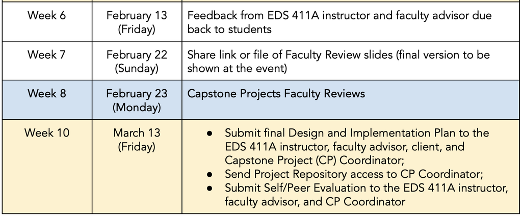

Advisor Check-ins

- Each capstone group sent their advisor a link to their draft Design and Implementation Plan (DIP) last Friday. Feedback from advisors on this document is due this Friday 2/13. I’ve read a previous draft of most sections and will give them broad feedback in this revision after you have added your comments.
- Remember, the DIP should be a *concrete and realistic* statement of what the group will do to solve the assigned problem for their client. Please encourage them to be *specific and detailed*. For context about each section of the DIP, please refer to the [Capstone guidelines](https://bren.ucsb.edu/sites/default/files/Capstone%20Project%20Guidelines%20MEDS%202026.pdf).
- Faculty reviews will take place on Monday 2/23 ([schedule with reviewers](https://docs.google.com/presentation/d/1m3kzFVfnq8SO-ayp21qjRHAR_OdeNvzhLf790Gxoy68/edit?usp=share_link)). They will consist of a 15-minute presentation + 25-minute discussion with two Bren faculty reviewers providing feedback ([rubric](https://docs.google.com/document/d/1Zw0xi5TtVp7ENKiudGMXSzoed9Kfk-3HD6GGWyB_c18/edit?usp=sharing)). This is an opportunity for students to 1) obtain feedback about their objectives, approach, and methods and 2) show they have completed steps towards building their deliverables.
- Help your students prepare for their presentations by discussing their slides with them and allocating time fior a practice presentation. Student presentations should have a clear exposition of the problem or knowledge gap to be addressed, detailed objectives, and concrete deliverables or research questions!

In 411A Today [(slides @ website)](https://meds-eds-411.github.io/eds-411-website/411a_winter/week6.html)

- Each group gave a practice faculty review presentation (15 minutes) and received feedback from their peers and myself (5 minutes).
- Each group will receive a document from me with feedback about their slides

Tasks all groups are expected to complete before next 411A class:

- Prepare version 2.0 of their faculty review presentation.
- Discuss which kind of questions they will get and prepare for answering them. Review Alex Phillips presentation on [strategies for a successful Q&A session](https://docs.google.com/presentation/d/1zkMLaWKjU0ENZsVdoLgn1Js8xKFsd2kkUiGpuWBtspc/edit?usp=sharing).
- Keep working on updating their DIP.
- Discuss in their next internal team meeting what is going well and what could be improved in how they’re working as a team.
- Advance their prototype and preliminary results.